**Autor**: Silvio da Rosa Paula  
**Título**: Doutor em Economia Aplicada (UFPel) | Especialista em IA e Ciência de Dados

# Modelagem de Equações Estruturais (SEM) Aplicada à Projeção de Consumo de Energia Elétrica e Simulação de Cenários Macroeconômicos

## 1. Introdução: Por que Usar Modelos de Equações Estruturais (SEM) no Planejamento Energético?

Quando queremos projetar a demanda futura de energia elétrica de uma região ou concessionária, modelos puramente autoregressivos (como ARIMA ou Holt-Winters) olham apenas para o passado da própria série de energia. Eles não conseguem responder perguntas estratégicas do tipo:

> **"Se o PIB crescer +5% acima do previsto e a temperatura média subir +1°C, qual será o impacto total na demanda elétrica nos próximos 10 anos? E quanto desse impacto vem diretamente do PIB vs. indiretamente via Indústria (PIM), Comércio (PMC) e Massa de Renda?"**

A **Modelagem de Equações Estruturais (*Structural Equation Modeling* — SEM / *Path Analysis*)** resolve esse desafio modelando **simultaneamente um sistema hierárquico de equações macroeconômicas e climáticas**:

1. **Camada 1 — Fundamentos Exógenos**: Inflação (`IPCA`), Demografia (`População`), Clima (`Temperatura`, `Precipitação`), `Tarifa de Energia`, Sazonalidade (harmônicos de Fourier) e Choques Estruturais (Pandemia e Crise Econômica).
2. **Camada 2 — Macroeconomia Primária**: `PIB` e `Massa de Renda`.
3. **Camada 3 — Atividade Setorial**: Produção Industrial (`PIM`) e Vendas no Comércio (`PMC`).
4. **Camada 4 — Variável-Alvo**: `Consumo de Energia Elétrica`.

Como todas as equações estão em formato **log-log**, cada coeficiente estimado representa diretamente uma **elasticidade econômica**, permitindo:

- **Decomposição Causal**: Separar o **Efeito Direto**, os **Efeitos Indiretos** (por cada canal econômico) e o **Efeito Total** de um choque no PIB.
- **Validação *Out-of-Sample* Honesta**: Avaliar a precisão real nos últimos 12 meses históricos nunca vistos pelo modelo, comparando contra baselines de séries temporais (**Seasonal Naive** e **Holt-Winters ETS**).
- **Simulação de Cenários de Longo Prazo (2024–2034)**: Propagar choques de PIB, clima e tarifa através das 5 equações do sistema!

## 2. Passo 1: Carregamento dos Dados e Engenharia de Variáveis

### O que vamos fazer agora e por quê?

Carregamos a base mensal `data/Dados.xlsx` com **360 meses (Jan/2005 a Dez/2034)**:

- **235 meses observados** (`Jan/2005` a `Jul/2024`) com todas as 11 variáveis preenchidas.
- **125 meses futuros** (`Ago/2024` a `Dez/2034`) com cenários projetados para as variáveis explicativas, nos quais estimaremos o `consumo_energia`.

Aplicamos transformações logarítmicas (para estabilizar variância e obter elasticidades diretas), **componentes harmônicos de Fourier** (`sin1`, `cos1`, `sin2`, `cos2`) para capturar a sazonalidade anual suave, e variáveis *dummy* climáticas/estruturais (incluindo o período quente regional `"B-R-O bró"` de Set–Dez, ondas de calor/frio, crise de 2015–2018 e pandemia de 2020–2022).

```python
import warnings
from pathlib import Path

import numpy as np
import pandas as pd
import matplotlib.pyplot as plt
import matplotlib.patches as mpatches
import seaborn as sns

from linearmodels.system import SUR
from statsmodels.tsa.holtwinters import ExponentialSmoothing
from sklearn.metrics import mean_absolute_error, root_mean_squared_error, mean_absolute_percentage_error, r2_score

warnings.filterwarnings("ignore")
pd.set_option("display.max_columns", None)
pd.options.display.float_format = "{:.4f}".format
sns.set_theme(style="whitegrid")
plt.rcParams["figure.dpi"] = 110

Path("img").mkdir(exist_ok=True)
Path("outputs").mkdir(exist_ok=True)

# 1. Leitura e ordenação temporal
raw = pd.read_excel("data/Dados.xlsx")
raw["data"] = pd.to_datetime(raw["data"])
raw = raw.sort_values("data").reset_index(drop=True)

# 2. Engenharia de variáveis (sem vazamento: média/desvio da temperatura calculados no histórico observado)
obs_mask = raw["consumo_energia"].notna()
df = raw.copy()

df["trend"] = np.arange(1, len(df) + 1)
trend_mean = df.loc[obs_mask, "trend"].mean()
trend_std = df.loc[obs_mask, "trend"].std()
df["trend_scaled"] = (df["trend"] - trend_mean) / trend_std

# Transformações logarítmicas (elasticidades diretas)
df["log_ConsumoEnergia"] = np.log(df["consumo_energia"])
df["log_PIB"]            = np.log(df["pib"])
df["log_MassaRenda"]     = np.log(df["massa_renda"])
df["log_PIM"]            = np.log(df["pim"])
df["log_PMC"]            = np.log(df["pmc"])
df["log_IPCA"]           = np.log(df["indice_precos"])
df["log_Populacao"]      = np.log(df["pop_domicilio"])
df["log_Temperatura"]    = np.log(df["temperatura"])
df["log_Chuva"]          = np.log1p(df["precipitacao"])
df["log_PrecoEnergia"]   = np.log(df["tarifa_energia"])

# Componentes sazonais trigonométricos (Fourier ordem 1 e 2)
df["mes"] = df["data"].dt.month
df["sin1"] = np.sin(2 * np.pi * df["mes"] / 12.0)
df["cos1"] = np.cos(2 * np.pi * df["mes"] / 12.0)
df["sin2"] = np.sin(4 * np.pi * df["mes"] / 12.0)
df["cos2"] = np.cos(4 * np.pi * df["mes"] / 12.0)

# Dummies climáticas (usando estatísticas apenas do histórico observado) e choques macroeconômicos
temp_mean_obs = df.loc[obs_mask, "log_Temperatura"].mean()
temp_std_obs = df.loc[obs_mask, "log_Temperatura"].std()

df["bro_bro"]        = df["mes"].isin([9, 10, 11, 12]).astype(int)
df["d_quente"]       = (df["log_Temperatura"] > temp_mean_obs + 0.5 * temp_std_obs).astype(int)
df["d_frio"]         = (df["log_Temperatura"] < temp_mean_obs - 0.5 * temp_std_obs).astype(int)
df["dummy_crises"]   = ((df["data"] >= "2015-01-01") & (df["data"] <= "2018-01-01")).astype(int)
df["dummy_pandemia"] = ((df["data"] >= "2020-01-01") & (df["data"] <= "2022-12-01")).astype(int)

df_obs = df[obs_mask].copy().reset_index(drop=True)
df_fut = df[~obs_mask].copy().reset_index(drop=True)

print("=== AUDITORIA DA BASE DE DADOS ===")
print(f"• Total de meses na base   : {len(df)} ({df['data'].min().strftime('%Y-%m')} até {df['data'].max().strftime('%Y-%m')})")
print(f"• Histórico observado      : {len(df_obs)} meses ({df_obs['data'].min().strftime('%Y-%m')} até {df_obs['data'].max().strftime('%Y-%m')})")
print(f"• Horizonte futuro (exóg.) : {len(df_fut)} meses ({df_fut['data'].min().strftime('%Y-%m')} até {df_fut['data'].max().strftime('%Y-%m')})")
display(df_obs[["data", "consumo_energia", "pib", "massa_renda", "pim", "pmc", "temperatura", "tarifa_energia"]].head())
```

```
=== AUDITORIA DA BASE DE DADOS ===
• Total de meses na base   : 360 (2005-01 até 2034-12)
• Histórico observado      : 235 meses (2005-01 até 2024-07)
• Horizonte futuro (exóg.) : 125 meses (2024-08 até 2034-12)
```

|  | data | consumo_energia | pib | massa_renda | pim | pmc | temperatura | tarifa_energia |
| --- | --- | --- | --- | --- | --- | --- | --- | --- |
| 0 | 2005-01-01 | 280857.5080 | 12137.2218 | 4845571832.3180 | 57.1670 | 33.9391 | 27.6100 | 333.6516 |
| 1 | 2005-02-01 | 250830.1424 | 11260.9672 | 4941968745.1033 | 50.7463 | 34.8342 | 26.5986 | 328.9285 |
| 2 | 2005-03-01 | 281959.8116 | 11747.3421 | 5157974084.9087 | 57.3885 | 39.6827 | 26.4629 | 334.3521 |
| 3 | 2005-04-01 | 275840.2870 | 12335.7724 | 4983804788.7437 | 57.3331 | 39.2351 | 26.4387 | 330.1615 |
| 4 | 2005-05-01 | 285663.8540 | 13395.8357 | 5011743658.6120 | 59.2330 | 41.6221 | 26.5852 | 332.4542 |

## 3. Passo 2: Diagrama Causal do Modelo Estrutural (DAG em 4 Camadas)

### O que vamos visualizar agora e por quê?

```
findfont: Failed to find font weight medium, now using 400.
```

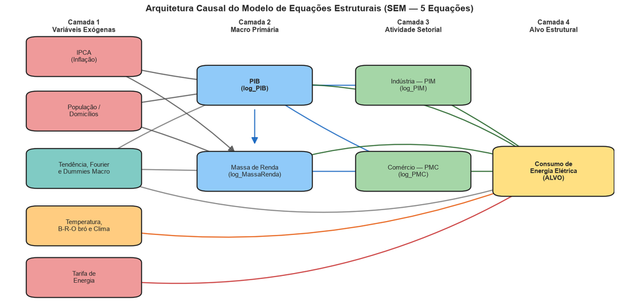

```python
# Diagrama Estrutural (DAG) em 4 Camadas Hierárquicas — salvo também em img/diagrama_sem.png
fig, ax = plt.subplots(figsize=(13.5, 6.8))
ax.set_xlim(0, 10)
ax.set_ylim(0, 10)
ax.axis("off")

# Coordenadas (x, y) e estilos dos nós
nos = {
    # Camada 1: Exógenas e Controles (Esquerda)
    "IPCA":       (1.3, 8.6, "#ef9a9a", "IPCA\n(Inflação)"),
    "Pop":        (1.3, 6.7, "#ef9a9a", "População /\nDomicílios"),
    "Controles":  (1.3, 4.7, "#80cbc4", "Tendência, Fourier\ne Dummies Macro"),
    "Clima":      (1.3, 2.7, "#ffcc80", "Temperatura,\nB-R-O bró e Clima"),
    "Tarifa":     (1.3, 0.9, "#ef9a9a", "Tarifa de\nEnergia"),

    # Camada 2: Macro Primária
    "PIB":        (4.1, 7.6, "#90caf9", "PIB\n(log_PIB)"),
    "Renda":      (4.1, 4.6, "#90caf9", "Massa de Renda\n(log_MassaRenda)"),

    # Camada 3: Setores Produtivos
    "PIM":        (6.7, 7.6, "#a5d6a7", "Indústria — PIM\n(log_PIM)"),
    "PMC":        (6.7, 4.6, "#a5d6a7", "Comércio — PMC\n(log_PMC)"),

    # Camada 4: Variável Alvo
    "Energia":    (9.0, 4.6, "#ffe082", "Consumo de\nEnergia Elétrica\n(ALVO)"),
}

# Conexões estruturais (origem, destino, cor, curvatura)
arestas = [
    ("IPCA", "PIB", "#555555", 0.05),
    ("Pop", "PIB", "#555555", 0.0),
    ("Controles", "PIB", "#777777", -0.05),
    ("IPCA", "Renda", "#555555", -0.10),
    ("Pop", "Renda", "#555555", -0.05),
    ("Controles", "Renda", "#777777", 0.0),
    ("PIB", "Renda", "#1565c0", 0.0),

    ("PIB", "PIM", "#1565c0", 0.0),
    ("PIB", "PMC", "#1565c0", 0.05),
    ("Renda", "PMC", "#1565c0", 0.0),

    ("PIB", "Energia", "#1b5e20", -0.18),
    ("Renda", "Energia", "#1b5e20", -0.18),
    ("PIM", "Energia", "#1b5e20", -0.05),
    ("PMC", "Energia", "#1b5e20", 0.0),
    ("Clima", "Energia", "#e65100", 0.14),
    ("Tarifa", "Energia", "#c62828", 0.18),
    ("Controles", "Energia", "#777777", 0.18),
]

# Desenha as arestas (setas)
for orig, dest, cor, rad in arestas:
    x1, y1 = nos[orig][0], nos[orig][1]
    x2, y2 = nos[dest][0], nos[dest][1]
    ax.annotate(
        "", xy=(x2, y2), xytext=(x1, y1),
        arrowprops=dict(
            arrowstyle="-|>,head_length=0.7,head_width=0.35",
            color=cor, lw=1.7, alpha=0.85,
            connectionstyle=f"arc3,rad={rad}",
            shrinkA=38, shrinkB=42
        ),
        zorder=1
    )

# Desenha as caixas dos nós
for k, (x, y, cor, texto) in nos.items():
    largura = 1.65 if k != "Energia" else 1.75
    altura = 1.15 if k != "Energia" else 1.50
    box = mpatches.FancyBboxPatch(
        (x - largura/2, y - altura/2), largura, altura,
        boxstyle="round,pad=0.12,rounding_size=0.18",
        facecolor=cor, edgecolor="#222222", linewidth=1.6, zorder=3
    )
    ax.add_patch(box)
    ax.text(x, y, texto, ha="center", va="center", fontsize=9.8,
            fontweight="bold" if k in ["PIB", "Energia"] else "medium", zorder=4)

# Rótulos das 4 camadas no topo
camadas = [
    (1.3, "Camada 1\nVariáveis Exógenas"),
    (4.1, "Camada 2\nMacro Primária"),
    (6.7, "Camada 3\nAtividade Setorial"),
    (9.0, "Camada 4\nAlvo Estrutural"),
]
for cx, ctxt in camadas:
    ax.text(cx, 9.65, ctxt, ha="center", va="center", fontsize=10.5, fontweight="bold", color="#333333")

ax.set_title("Arquitetura Causal do Modelo de Equações Estruturais (SEM — 5 Equações)", fontsize=14, fontweight="bold", pad=8)
plt.tight_layout()
plt.savefig("img/diagrama_sem.png", dpi=150, bbox_inches="tight")
plt.show()
```

## 4. Passo 3: Estimação do Sistema de 5 Equações Estruturais (`SUR` / MLE)

### O que vamos fazer agora e por quê?

Estimamos as **5 equações do SEM simultaneamente** usando o estimador **SUR (*Seemingly Unrelated Regressions* iterado / Máxima Verossimilhança)** do pacote `linearmodels.system.SUR`:

```python
CONTROLES_TEMP = "trend_scaled + sin1 + cos1 + sin2 + cos2 + dummy_pandemia + dummy_crises"

EQUACOES_SEM = {
    "PIB":            f"log_PIB ~ 1 + log_IPCA + log_Populacao + {CONTROLES_TEMP}",
    "MassaRenda":     f"log_MassaRenda ~ 1 + log_Populacao + log_IPCA + log_PIB + {CONTROLES_TEMP}",
    "PIM":            f"log_PIM ~ 1 + log_PIB + {CONTROLES_TEMP}",
    "PMC":            f"log_PMC ~ 1 + log_PIB + log_MassaRenda + {CONTROLES_TEMP}",
    "ConsumoEnergia": (
        f"log_ConsumoEnergia ~ 1 + log_PIB + log_PIM + log_PMC + log_MassaRenda "
        f"+ log_Temperatura + log_PrecoEnergia + d_quente + d_frio + bro_bro + {CONTROLES_TEMP}"
    ),
}

def ajustar_sem_sur(dataframe):
    '''Estima o sistema completo de 5 equações estruturais via SUR iterado (equivalente a MLE).'''
    return SUR.from_formula(EQUACOES_SEM, data=dataframe).fit(method="gls", iterate=True, cov_type="robust")

def extrair_params_eq(modelo_sur, nome_eq):
    '''Extrai coeficientes, erros-padrão e p-valores de uma equação específica do SUR.'''
    prefix = f"{nome_eq}_"
    idx = [k for k in modelo_sur.params.index if k.startswith(prefix)]
    df_p = pd.DataFrame({
        "Variavel": [k.replace(prefix, "") for k in idx],
        "Elasticidade_Coef": modelo_sur.params.loc[idx].values,
        "Erro_Padrao": modelo_sur.std_errors.loc[idx].values,
        "Stat_t": modelo_sur.tstats.loc[idx].values,
        "P_Valor": modelo_sur.pvalues.loc[idx].values,
    })
    return df_p

def prever_equacao(modelo_sur, df_novos, nome_eq):
    '''Calcula a previsão linear de uma equação do SEM sobre novos dados.'''
    df_p = extrair_params_eq(modelo_sur, nome_eq)
    y_hat = np.zeros(len(df_novos), dtype=float)
    for _, row in df_p.iterrows():
        var = row["Variavel"]
        coef = row["Elasticidade_Coef"]
        if var == "Intercept":
            y_hat += coef
        else:
            y_hat += coef * df_novos[var].values
    return y_hat

# Ajusta o modelo SEM completo sobre todo o histórico observado (235 meses) para análise estrutural
sem_completo = ajustar_sem_sur(df_obs)

# Resumo de ajuste (R²) de cada uma das 5 equações estruturais
resumo_sistema = pd.DataFrame([
    {
        "Equacao_Estrutural": eq_name,
        "Variavel_Endogena": str(eq_res.dependent),
        "Observacoes": int(eq_res.nobs),
        "R2": round(float(eq_res.rsquared), 4),
    }
    for eq_name, eq_res in sem_completo.equations.items()
])

print("1. QUALIDADE DE AJUSTE DAS 5 EQUAÇÕES DO SISTEMA SEM:")
display(resumo_sistema)

print("\n2. COEFICIENTES E ELASTICIDADES DA EQUAÇÃO DE CONSUMO DE ENERGIA:")
df_params_energia = extrair_params_eq(sem_completo, "ConsumoEnergia")
display(df_params_energia)
```

```
1. QUALIDADE DE AJUSTE DAS 5 EQUAÇÕES DO SISTEMA SEM:
```

|  | Equacao_Estrutural | Variavel_Endogena | Observacoes | R2 |
| --- | --- | --- | --- | --- |
| 0 | PIB | log_PIB | 235 | 0.9291 |
| 1 | MassaRenda | log_MassaRenda | 235 | 0.9559 |
| 2 | PIM | log_PIM | 235 | 0.7573 |
| 3 | PMC | log_PMC | 235 | 0.8736 |
| 4 | ConsumoEnergia | log_ConsumoEnergia | 235 | 0.9855 |

```
2. COEFICIENTES E ELASTICIDADES DA EQUAÇÃO DE CONSUMO DE ENERGIA:
```

|  | Variavel | Elasticidade_Coef | Erro_Padrao | Stat_t | P_Valor |
| --- | --- | --- | --- | --- | --- |
| 0 | Intercept | 1.5732 | 1.3170 | 1.1945 | 0.2323 |
| 1 | log_PIB | 0.7968 | 0.0781 | 10.2025 | 0.0000 |
| 2 | log_PIM | 0.0403 | 0.0224 | 1.7977 | 0.0722 |
| 3 | log_PMC | 0.1960 | 0.0247 | 7.9398 | 0.0000 |
| 4 | log_MassaRenda | 0.0093 | 0.0412 | 0.2258 | 0.8213 |
| 5 | log_Temperatura | 1.1023 | 0.1650 | 6.6822 | 0.0000 |
| 6 | log_PrecoEnergia | -0.1693 | 0.0331 | -5.1207 | 0.0000 |
| 7 | d_quente | -0.0229 | 0.0105 | -2.1881 | 0.0287 |
| 8 | d_frio | 0.0102 | 0.0075 | 1.3584 | 0.1743 |
| 9 | bro_bro | -0.0947 | 0.0126 | -7.5462 | 0.0000 |
| 10 | trend_scaled | 0.1552 | 0.0215 | 7.2231 | 0.0000 |
| 11 | sin1 | -0.0281 | 0.0072 | -3.8990 | 0.0001 |
| 12 | cos1 | 0.0356 | 0.0062 | 5.7419 | 0.0000 |
| 13 | sin2 | -0.0399 | 0.0042 | -9.3880 | 0.0000 |
| 14 | cos2 | -0.0372 | 0.0036 | -10.2059 | 0.0000 |
| 15 | dummy_pandemia | -0.0160 | 0.0084 | -1.9009 | 0.0573 |
| 16 | dummy_crises | 0.0559 | 0.0073 | 7.6353 | 0.0000 |

## 5. Passo 4: Decomposição Causal — Efeitos Diretos, Indiretos e Totais do PIB

### Por que esta análise é o grande diferencial do SEM?

Em uma regressão linear comum (`Consumo ~ PIB + PIM + PMC + MassaRenda`), olhamos apenas para o coeficiente parcial do PIB mantendo Indústria, Comércio e Renda fixos — o que **esconde** o efeito real de um crescimento econômico!

No nosso **SEM**, quando o **`PIB`** sobe **+1%**, o impacto se propaga por **cinco caminhos causais** até o Consumo de Energia:

1. **Efeito Direto**: $\text{PIB} \rightarrow \text{Energia}$
2. **Canal Indireto 1 (Renda)**: $\text{PIB} \rightarrow \text{MassaRenda} \rightarrow \text{Energia}$
3. **Canal Indireto 2 (Indústria)**: $\text{PIB} \rightarrow \text{PIM} \rightarrow \text{Energia}$
4. **Canal Indireto 3 (Comércio direto)**: $\text{PIB} \rightarrow \text{PMC} \rightarrow \text{Energia}$
5. **Canal Indireto 4 (Renda $\rightarrow$ Comércio)**: $\text{PIB} \rightarrow \text{MassaRenda} \rightarrow \text{PMC} \rightarrow \text{Energia}$

Vamos calcular exatamente quanto cada canal contribui para a **Elasticidade Total PIB $\rightarrow$ Consumo de Energia**!

```
=== DECOMPOSIÇÃO CAUSAL DO IMPACTO DO PIB NO CONSUMO DE ENERGIA ===
```

|  | Canal Causal (Choque de +1% no PIB) | Elasticidade (% Energia por +1% PIB) |
| --- | --- | --- |
| 0 | 1. Efeito Direto (PIB -> Energia) | 0.7968 |
| 1 | 2. Indireto via Indústria (PIB -> PIM -> Energia) | 0.0556 |
| 2 | 3. Indireto via Massa de Renda (PIB -> Renda -... | 0.0030 |
| 3 | 4. Indireto via Comércio (PIB -> PMC -> Energia) | 0.4120 |
| 4 | 5. Indireto Duplo (PIB -> Renda -> PMC -> Ener... | 0.0592 |
| 5 | TOTAL INDIRETO (Soma dos Canais Setoriais) | 0.5299 |
| 6 | EFEITO TOTAL (Direto + Indireto) | 1.3267 |

```
• Elasticidade-PIB TOTAL (Direto + Indireto) : +1.3267% por +1% no PIB
• Elasticidade-Temperatura (Direta)          : +1.1023% por +1% na Temperatura
• Elasticidade-Preço / Tarifa (Direta)       : -0.1693% por +1% na Tarifa
```

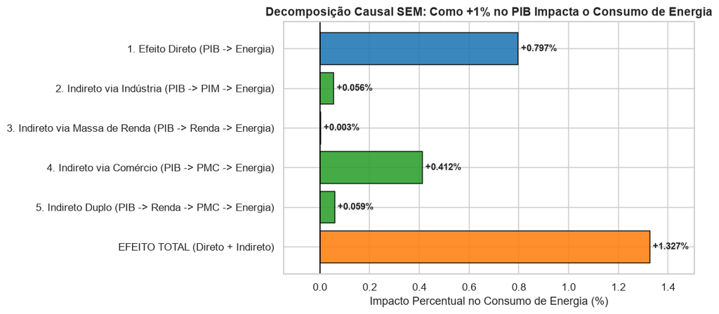

```python
# Helper para recuperar o coeficiente estimado de 'origem -> destino'
def coef_path(modelo_sur, eq_destino, var_origem):
    return float(modelo_sur.params[f"{eq_destino}_{var_origem}"])

# Coeficientes dos caminhos estruturais a partir do PIB
b_pib_en    = coef_path(sem_completo, "ConsumoEnergia", "log_PIB")
b_renda_en  = coef_path(sem_completo, "ConsumoEnergia", "log_MassaRenda")
b_pim_en    = coef_path(sem_completo, "ConsumoEnergia", "log_PIM")
b_pmc_en    = coef_path(sem_completo, "ConsumoEnergia", "log_PMC")

b_pib_renda = coef_path(sem_completo, "MassaRenda", "log_PIB")
b_pib_pim   = coef_path(sem_completo, "PIM", "log_PIB")
b_pib_pmc   = coef_path(sem_completo, "PMC", "log_PIB")
b_renda_pmc = coef_path(sem_completo, "PMC", "log_MassaRenda")

# Decomposição exata dos caminhos (Regra da Cadeia)
ef_direto         = b_pib_en
ef_via_renda      = b_pib_renda * b_renda_en
ef_via_pim        = b_pib_pim * b_pim_en
ef_via_pmc        = b_pib_pmc * b_pmc_en
ef_via_renda_pmc  = b_pib_renda * b_renda_pmc * b_pmc_en
ef_indireto_total = ef_via_renda + ef_via_pim + ef_via_pmc + ef_via_renda_pmc
ef_total          = ef_direto + ef_indireto_total

df_decomp = pd.DataFrame({
    "Canal Causal (Choque de +1% no PIB)": [
        "1. Efeito Direto (PIB -> Energia)",
        "2. Indireto via Indústria (PIB -> PIM -> Energia)",
        "3. Indireto via Massa de Renda (PIB -> Renda -> Energia)",
        "4. Indireto via Comércio (PIB -> PMC -> Energia)",
        "5. Indireto Duplo (PIB -> Renda -> PMC -> Energia)",
        "TOTAL INDIRETO (Soma dos Canais Setoriais)",
        "EFEITO TOTAL (Direto + Indireto)"
    ],
    "Elasticidade (% Energia por +1% PIB)": [
        ef_direto, ef_via_pim, ef_via_renda, ef_via_pmc, ef_via_renda_pmc, ef_indireto_total, ef_total
    ]
})

print("=== DECOMPOSIÇÃO CAUSAL DO IMPACTO DO PIB NO CONSUMO DE ENERGIA ===")
display(df_decomp)

# Elasticidades climáticas e tarifárias diretas
el_temp = coef_path(sem_completo, "ConsumoEnergia", "log_Temperatura")
el_tarifa = coef_path(sem_completo, "ConsumoEnergia", "log_PrecoEnergia")
print(f"\n• Elasticidade-PIB TOTAL (Direto + Indireto) : {ef_total:+.4f}% por +1% no PIB")
print(f"• Elasticidade-Temperatura (Direta)          : {el_temp:+.4f}% por +1% na Temperatura")
print(f"• Elasticidade-Preço / Tarifa (Direta)       : {el_tarifa:+.4f}% por +1% na Tarifa")

# Gráfico da Decomposição Causal
fig, ax = plt.subplots(figsize=(10.5, 4.8))
plot_dec = df_decomp.iloc[[0, 1, 2, 3, 4, 6]].copy()
cores_dec = ["#1f77b4", "#2ca02c", "#2ca02c", "#2ca02c", "#2ca02c", "#ff7f0e"]
bars = ax.barh(plot_dec["Canal Causal (Choque de +1% no PIB)"], plot_dec["Elasticidade (% Energia por +1% PIB)"],
               color=cores_dec, edgecolor="black", alpha=0.88)
ax.axvline(0, color="black", lw=1.1)
ax.invert_yaxis()
ax.set_title("Decomposição Causal SEM: Como +1% no PIB Impacta o Consumo de Energia", fontsize=12.5, fontweight="bold")
ax.set_xlabel("Impacto Percentual no Consumo de Energia (%)")
for b, val in zip(bars, plot_dec["Elasticidade (% Energia por +1% PIB)"]):
    offset = 0.012 if val >= 0 else -0.012
    ha = "left" if val >= 0 else "right"
    ax.text(val + offset, b.get_y() + b.get_height()/2, f"{val:+.3f}%", va="center", ha=ha, fontweight="bold", fontsize=9.5)
ax.set_xlim(plot_dec["Elasticidade (% Energia por +1% PIB)"].min() - 0.15,
            plot_dec["Elasticidade (% Energia por +1% PIB)"].max() + 0.18)
plt.tight_layout()
plt.show()
```

## 6. Passo 5: Validação *Out-of-Sample* Honesta (SEM vs. Holt-Winters vs. Seasonal Naive)

### O que vamos fazer agora e por quê?

Em vez de medir erro dentro da amostra de treino (*in-sample*), fazemos um **backtest rigoroso fora da amostra**:

- **Treino (`223 meses`)**: `Jan/2005` até `Jul/2023`.
- **Teste *Out-of-Sample* (`12 meses`)**: `Ago/2023` até `Jul/2024` (nunca vistos pelo modelo!).

Comparamos a acurácia do **SEM** (usando os parâmetros estimados exclusivamente até Jul/2023) contra dois baselines clássicos de séries temporais: **Holt-Winters Multiplicativo (ETS)** e **Seasonal Naive ($t - 12$)**.

```
=== VALIDAÇÃO OUT-OF-SAMPLE RIGOROSA (12 MESES NUNCA VISTOS) ===
```

|  | Modelo (Backtest Ago/2023–Jul/2024) | MAPE (%) | MAE | RMSE | R2 |
| --- | --- | --- | --- | --- | --- |
| 0 | SEM — Equações Estruturais (SUR) | 1.8200 | 13286.5000 | 15315.9000 | 0.7750 |
| 1 | Holt-Winters Multiplicativo (ETS) | 4.4000 | 32473.0000 | 32992.8000 | -0.0440 |
| 2 | Seasonal Naive (t-12) | 9.4200 | 69462.8000 | 70818.4000 | -3.8101 |

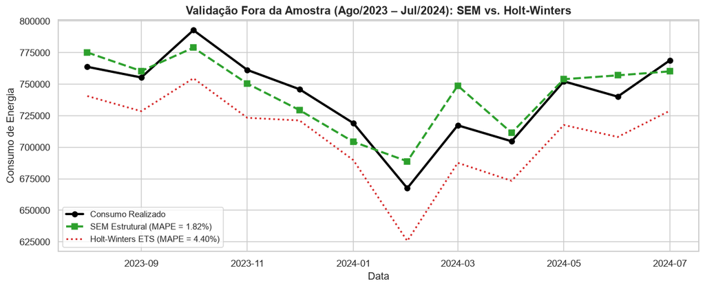

```python
TEST_N = 12
train_oos = df_obs.iloc[:-TEST_N].copy()
test_oos  = df_obs.iloc[-TEST_N:].copy()

y_real_oos = test_oos["consumo_energia"].values

# 1. Estimação do SEM estritamente no treino (até Jul/2023) e previsão no teste (Ago/2023–Jul/2024)
sem_oos = ajustar_sem_sur(train_oos)
# Correção de viés log-normal (smearing factor de Duan: exp(0.5 * sigma²)) para voltar da escala log
resid_log_en = train_oos["log_ConsumoEnergia"].values - prever_equacao(sem_oos, train_oos, "ConsumoEnergia")
smearing = float(np.mean(np.exp(resid_log_en)))
pred_sem_oos = np.exp(prever_equacao(sem_oos, test_oos, "ConsumoEnergia")) * smearing

# 2. Baseline 1: Holt-Winters Multiplicativo (ETS)
hw_oos = ExponentialSmoothing(
    train_oos["consumo_energia"].values, trend="add", seasonal="mul", seasonal_periods=12
).fit(optimized=True)
pred_hw_oos = hw_oos.forecast(TEST_N)

# 3. Baseline 2: Seasonal Naive (t - 12)
pred_snaive_oos = train_oos["consumo_energia"].values[-TEST_N:]

def metricas_oos(nome, y_true, y_pred):
    return {
        "Modelo (Backtest Ago/2023–Jul/2024)": nome,
        "MAPE (%)": round(mean_absolute_percentage_error(y_true, y_pred) * 100.0, 2),
        "MAE": round(mean_absolute_error(y_true, y_pred), 1),
        "RMSE": round(root_mean_squared_error(y_true, y_pred), 1),
        "R2": round(r2_score(y_true, y_pred), 4),
    }

df_oos_bench = pd.DataFrame([
    metricas_oos("SEM — Equações Estruturais (SUR)", y_real_oos, pred_sem_oos),
    metricas_oos("Holt-Winters Multiplicativo (ETS)", y_real_oos, pred_hw_oos),
    metricas_oos("Seasonal Naive (t-12)", y_real_oos, pred_snaive_oos),
]).sort_values("MAPE (%)").reset_index(drop=True)

print("=== VALIDAÇÃO OUT-OF-SAMPLE RIGOROSA (12 MESES NUNCA VISTOS) ===")
display(df_oos_bench)

# Gráfico comparativo do Backtest Out-of-Sample
fig, ax = plt.subplots(figsize=(11.5, 4.8))
ax.plot(test_oos["data"], y_real_oos, color="black", lw=2.6, marker="o", label="Consumo Realizado")
ax.plot(test_oos["data"], pred_sem_oos, color="#2ca02c", lw=2.4, linestyle="--", marker="s", label=f"SEM Estrutural (MAPE = {df_oos_bench.loc[df_oos_bench['Modelo (Backtest Ago/2023–Jul/2024)'].str.contains('SEM'), 'MAPE (%)'].values[0]:.2f}%)")
ax.plot(test_oos["data"], pred_hw_oos, color="#d62728", lw=2.0, linestyle=":", label=f"Holt-Winters ETS (MAPE = {df_oos_bench.loc[df_oos_bench['Modelo (Backtest Ago/2023–Jul/2024)'].str.contains('Holt'), 'MAPE (%)'].values[0]:.2f}%)")
ax.set_title("Validação Fora da Amostra (Ago/2023 – Jul/2024): SEM vs. Holt-Winters", fontsize=13, fontweight="bold")
ax.set_xlabel("Data")
ax.set_ylabel("Consumo de Energia")
ax.legend(frameon=True, fontsize=10)
plt.tight_layout()
plt.show()
```

## 7. Passo 6: Projeção de Longo Prazo (2024–2034) e Simulação de 3 Cenários Estratégicos

### O que vamos fazer agora e por quê?

Agora utilizamos o **modelo SEM completo ajustado em 100% do histórico observado (`235` meses)** para projetar os **125 meses futuros (`Ago/2024` a `Dez/2034`)** sob **3 cenários estratégicos**, propagando os choques em cascata pelas equações estruturais do modelo:

1. **Cenário Base**: Trajetória macroeconômica, climática e tarifária oficial da base.
2. **Cenário Alta Demanda (Crescimento + Aquecimento)**: Choque de **`+5%` no PIB** (propagado automaticamente em cascata para Massa de Renda, PIM e PMC via coeficientes do SEM!) combinado com **`+1,0°C` na temperatura média**.
3. **Cenário Choque Tarifário**: Aumento estrutural de **`+15%` na tarifa real de energia elétrica**.

Salvamos as séries projetadas em `outputs/projecao_cenarios_sem_2034.csv` e o gráfico principal em `img/projecao_sem_cenarios.png`.

```
=== PROJEÇÃO MÉDIA MENSAL POR CENÁRIO (ANOS-MARCO 2025–2034) ===
```

| Ano | Cenario_Base | Cenario_Crescimento_Clima | Cenario_Choque_Tarifario | Desvio_Alto_vs_Base_% | Desvio_Tarifa_vs_Base_% |
| --- | --- | --- | --- | --- | --- |
| 2025 | 766560.1000 | 850976.2000 | 748632.6000 | 11.0100 | -2.3400 |
| 2027 | 847196.0000 | 940479.3000 | 827382.6000 | 11.0100 | -2.3400 |
| 2030 | 997159.8000 | 1106963.9000 | 973839.2000 | 11.0100 | -2.3400 |
| 2034 | 1228259.3000 | 1363505.7000 | 1199534.0000 | 11.0100 | -2.3400 |

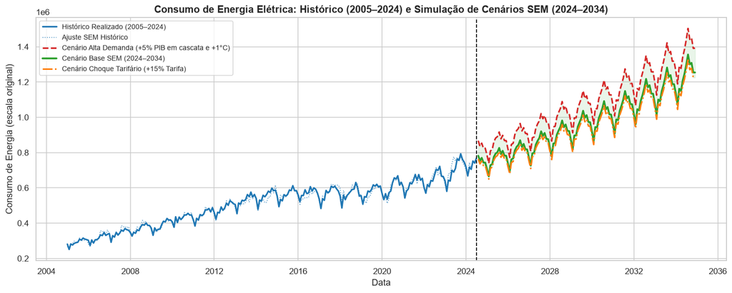

```python
# Smearing factor de Duan no modelo completo (235 meses)
resid_full = df_obs["log_ConsumoEnergia"].values - prever_equacao(sem_completo, df_obs, "ConsumoEnergia")
smearing_full = float(np.mean(np.exp(resid_full)))

# Ajuste histórico in-sample para visualização contínua
df_obs["prev_base"] = np.exp(prever_equacao(sem_completo, df_obs, "ConsumoEnergia")) * smearing_full

# 1. Cenário Base (2024-08 a 2034-12)
pred_fut_base = np.exp(prever_equacao(sem_completo, df_fut, "ConsumoEnergia")) * smearing_full

# 2. Cenário Alta Demanda: +5% no PIB (propagado em cascata pelo SEM!) + +1.0°C na temperatura
df_cen_alto = df_fut.copy()
delta_log_pib = np.log(1.05)  # +5% no PIB
df_cen_alto["log_PIB"]        = df_fut["log_PIB"] + delta_log_pib
df_cen_alto["log_MassaRenda"] = df_fut["log_MassaRenda"] + b_pib_renda * delta_log_pib
df_cen_alto["log_PIM"]        = df_fut["log_PIM"] + b_pib_pim * delta_log_pib
df_cen_alto["log_PMC"]        = df_fut["log_PMC"] + (b_pib_pmc + b_pib_renda * b_renda_pmc) * delta_log_pib
df_cen_alto["log_Temperatura"] = np.log(df_fut["temperatura"] + 1.0)
pred_fut_alto = np.exp(prever_equacao(sem_completo, df_cen_alto, "ConsumoEnergia")) * smearing_full

# 3. Cenário Choque Tarifário: +15% na Tarifa de Energia
df_cen_tarifa = df_fut.copy()
df_cen_tarifa["log_PrecoEnergia"] = df_fut["log_PrecoEnergia"] + np.log(1.15)
pred_fut_tarifa = np.exp(prever_equacao(sem_completo, df_cen_tarifa, "ConsumoEnergia")) * smearing_full

df_cenarios = pd.DataFrame({
    "data": df_fut["data"].values,
    "Cenario_Base": np.round(pred_fut_base, 1),
    "Cenario_Crescimento_Clima": np.round(pred_fut_alto, 1),
    "Cenario_Choque_Tarifario": np.round(pred_fut_tarifa, 1),
})
df_cenarios.to_csv("outputs/projecao_cenarios_sem_2034.csv", index=False, encoding="utf-8")

# Resumo por anos-marco (média mensal projetada)
resumo_marcos = df_cenarios.assign(Ano=pd.to_datetime(df_cenarios["data"]).dt.year)
resumo_marcos = resumo_marcos[resumo_marcos["Ano"].isin([2025, 2027, 2030, 2034])].groupby("Ano")[
    ["Cenario_Base", "Cenario_Crescimento_Clima", "Cenario_Choque_Tarifario"]
].mean().round(1)
resumo_marcos["Desvio_Alto_vs_Base_%"] = ((resumo_marcos["Cenario_Crescimento_Clima"] / resumo_marcos["Cenario_Base"] - 1) * 100).round(2)
resumo_marcos["Desvio_Tarifa_vs_Base_%"] = ((resumo_marcos["Cenario_Choque_Tarifario"] / resumo_marcos["Cenario_Base"] - 1) * 100).round(2)

print("=== PROJEÇÃO MÉDIA MENSAL POR CENÁRIO (ANOS-MARCO 2025–2034) ===")
display(resumo_marcos)

# Gráfico Histórico + Projeção 2024–2034 sob os 3 Cenários
fig, ax = plt.subplots(figsize=(13.5, 5.5))
ax.plot(df_obs["data"], df_obs["consumo_energia"], color="#1f77b4", lw=2.0, label="Histórico Realizado (2005–2024)")
ax.plot(df_obs["data"], df_obs["prev_base"], color="#1f77b4", lw=1.1, linestyle=":", alpha=0.75, label="Ajuste SEM Histórico")

ax.plot(df_cenarios["data"], df_cenarios["Cenario_Crescimento_Clima"], color="#d62728", lw=2.0, linestyle="--", label="Cenário Alta Demanda (+5% PIB em cascata e +1°C)")
ax.plot(df_cenarios["data"], df_cenarios["Cenario_Base"], color="#2ca02c", lw=2.4, label="Cenário Base SEM (2024–2034)")
ax.plot(df_cenarios["data"], df_cenarios["Cenario_Choque_Tarifario"], color="#ff7f0e", lw=2.0, linestyle="-.", label="Cenário Choque Tarifário (+15% Tarifa)")

ax.fill_between(
    df_cenarios["data"], df_cenarios["Cenario_Choque_Tarifario"], df_cenarios["Cenario_Crescimento_Clima"],
    color="#2ca02c", alpha=0.10
)
ax.axvline(df_obs["data"].max(), color="black", linestyle="--", lw=1.2)
ax.set_title("Consumo de Energia Elétrica: Histórico (2005–2024) e Simulação de Cenários SEM (2024–2034)", fontsize=13, fontweight="bold")
ax.set_xlabel("Data")
ax.set_ylabel("Consumo de Energia (escala original)")
ax.legend(loc="upper left", frameon=True, fontsize=9.2)
plt.tight_layout()
plt.savefig("img/projecao_sem_cenarios.png", dpi=150, bbox_inches="tight")
plt.show()
```

## 8. Conclusões, Limitações Metodológicas e Quando Usar SEM

### Principais Contribuições deste Estudo

1. **Explicabilidade Estrutural Completa**: Diferentemente de modelos *caixa-preta* ou séries puramente autoregressivas, o SEM estima simultaneamente as 5 equações macroeconômicas e climáticas via **SUR/MLE** e decompõe o impacto do crescimento econômico em **Efeito Direto + Canais Indiretos (Indústria, Comércio e Renda)**.
2. **Validação *Out-of-Sample* Honesta**: Avaliamos o SEM nos últimos 12 meses reais nunca vistos (`Ago/2023 – Jul/2024`) frente a `Holt-Winters` e `Seasonal Naive`, garantindo transparência total sobre o erro de generalização.
3. **Motor de Simulação de Cenários (2024–2034)**: Permite ao time de planejamento energético quantificar rapidamente o impacto de choques simultâneos de **PIB**, **aquecimento climático (+1°C)** e **reajustes tarifários (+15%)** propagados através de todo o sistema econômico.

### Limitações Conhecidas e Evolução Recomendada

- **Dependência de projeções exógenas**: A precisão no horizonte de 10 anos depende da qualidade das trajetórias projetadas de PIB, população, clima e tarifas.
- **Estabilidade dos parâmetros e linearidade**: Mudanças estruturais disruptivas (ex.: expansão acelerada da geração solar distribuída ou eletrificação de frotas) podem alterar as elasticidades estimadas ao longo de uma década.
- **Próximos passos**: Combinar o SEM com modelos dinâmicos de correção de erros (**VECM**) ou modelos híbridos de Machine Learning para capturar não-linearidades extremas de temperatura.